# Multi-Environment Trial (MET) Analysis

Guilherme Oliveira, Mandeep Singh, Subash Thapa

2024-11-05

# Multi-Environment Trial Analysis - PS 756 project

The following document was developed by Guilherme Oliveira, Mandeep Singh, Subash Thapa, students at South Dakota State University, as a requisite for the course PS 746 - Quantitative Genetics.

The main objective of this project was to conduct Multi Trial Analysis, covering i) GxE analysis (+ GGE analysis) ii) AMMI analysis, iii) GGI analysis, iv) FW analysis and v) genomic selection approach which explores in some way Genotype x Environment interaction (G x E).

For the parts i, ii, iii, iv, we are exploring the open dataset made available by Dias et al. (2018) which contains phenotypic data of five drought tolerance traits, measured in in 308 hybrids along eight environments contrasting for water availability. For practical purposes, we are using a subset of 202 hybrids. The traits analyzed were grain yield (GY), ears per plot (EPP), female and male flowering times (FFT and MFT), and anthesis-silking interval (ASI). The source code used is from the metan (Olivoto and Lucio, 2020) and statgenGxE reference manuals.

For the part v, we are exploring the open dataset made available by Crossa et al. 2013 and Montesinos-Lopez et al. 2016, 2017 which contains the data of 309 double-haploid maize lines conducted in 3 environments and each environments having 3 reps of each line. The traits analyzed were grain yield (yield), anthesis-silking interval (ASI) and plant height (PH). The source code used is from Montesinos-Lopez et al. 2019 using the BMTME R package, where we did just small modifications, however, bringing more interpretations and extra analyses.

## Directory

```r
setwd("C:/Users/Subash.thapa/Desktop/Quantitative Genetics/Project")
getwd()
```

```
## [1] "C:/Users/Subash.thapa/Desktop/Quantitative Genetics/Project"
```

## Libraries

The main libraries used for this project to run the Multi-Environment Trial Analysis.

```r
library(statgenGxE)
library(metan)
library(tibble)
```

```r
library(ggplot2)
library(tidyverse)
library(lme4)
```

## Data

The “pheno” is the dataset which will be used for the parts i, ii, iii, iv while the “G.Maize” and “Data.Maize” will be used for the part v.

```r
pheno <- read.table("pheno_corn_MET.txt", header = TRUE)
load("C:/Users/Subash.thapa/Desktop/Quantitative Genetics/Project/G.Maize.RData")
load("C:/Users/Subash.thapa/Desktop/Quantitative Genetics/Project/Data.Maize.RDATa")
```

### Data preparation and exploration

Before running the parts i, ii, iii, iv, we need to check some very important points. First, we need to check our “pheno” structure, normality, distribution, descriptive statistics etc.

To complete these tasks, we are using some R basic functions + some functions inside the metan package.

## Data strcture

In this analysis the ENV, GEN, REP should be factors, while the traits should be numeric. Also we need, to change our phenotypic data frame to a tibble, being able to run the metan functions.

```r
str(pheno)
```

```
## 'data.frame':    3434 obs. of  8 variables:
##  $ ENV: chr  "E1" "E2" "E3" "E4" ...
##  $ REP: int  1 1 1 1 1 1 1 1 2 2 ...
##  $ GEN: int  1 1 1 1 1 1 1 1 1 1 ...
##  $ FFT: int  66 62 69 70 63 55 54 56 65 63 ...
##  $ MFT: int  62 61 66 69 50 52 51 53 63 62 ...
##  $ ASI: int  4 1 3 1 13 3 3 3 2 1 ...
##  $ EPP: int  12 18 13 15 7 15 13 7 12 16 ...
##  $ GY : num  1.91 6.63 3.63 5.6 0.97 4.64 4.5 2.55 3.6 5.53 ...
```

```r
pheno$ENV <- as.factor(pheno$ENV)
pheno$GEN <- as.factor(pheno$GEN)
pheno$REP <- as.factor(pheno$REP)
pheno$FFT <- as.numeric(pheno$FFT)
pheno$MFT <- as.numeric(pheno$MFT)
pheno$ASI <- as.numeric(pheno$ASI)
pheno$EPP <- as.numeric(pheno$EPP)
pheno <- as_tibble(pheno)

str(pheno)
```

```
## tibble [3,434 × 8] (S3: tbl_df/tbl/data.frame)
##  $ ENV: Factor w/ 8 levels "E1","E2","E3",..: 1 2 3 4 5 6 7 8 1 2 ...
##  $ REP: Factor w/ 3 levels "1","2","3": 1 1 1 1 1 1 1 1 2 2 ...
##  $ GEN: Factor w/ 202 levels "1","3","4","8",..: 1 1 1 1 1 1 1 1 1 1 ...
##  $ FFT: num [1:3434] 66 62 69 70 63 55 54 56 65 63 ...
##  $ MFT: num [1:3434] 62 61 66 69 50 52 51 53 63 62 ...
##  $ ASI: num [1:3434] 4 1 3 1 13 3 3 3 2 1 ...
##  $ EPP: num [1:3434] 12 18 13 15 7 15 13 7 12 16 ...
##  $ GY : num [1:3434] 1.91 6.63 3.63 5.6 0.97 4.64 4.5 2.55 3.6 5.53 ...
```

## Data normality

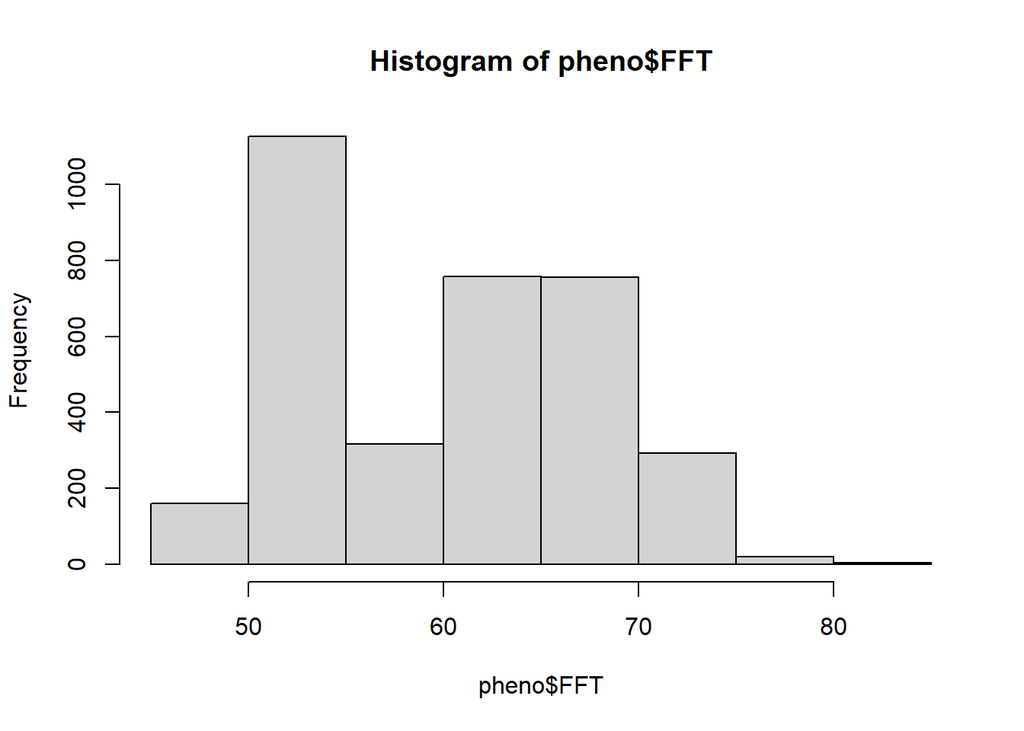

```r
hist(pheno$FFT)
```

```r
shapiro.test(pheno$FFT)
```

```
##
##  Shapiro-Wilk normality test
##
## data:  pheno$FFT
## W = 0.93568, p-value < 2.2e-16
```

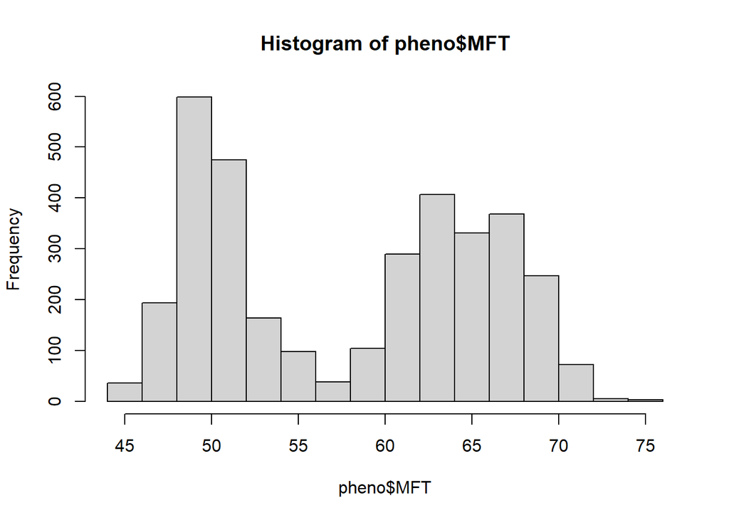

```r
hist(pheno$MFT)
```

```r
shapiro.test(pheno$MFT)
```

```
##
##  Shapiro-Wilk normality test
##
## data:  pheno$MFT
## W = 0.89781, p-value < 2.2e-16
```

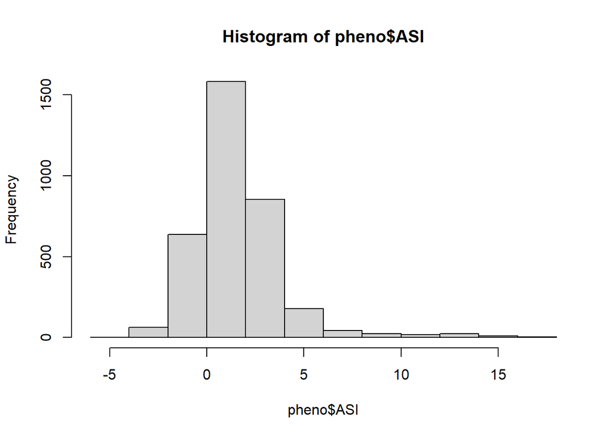

```r
hist(pheno$ASI)
```

```r
shapiro.test(pheno$ASI)
```

```
##
##  Shapiro-Wilk normality test
##
## data:  pheno$ASI
## W = 0.82689, p-value < 2.2e-16
```

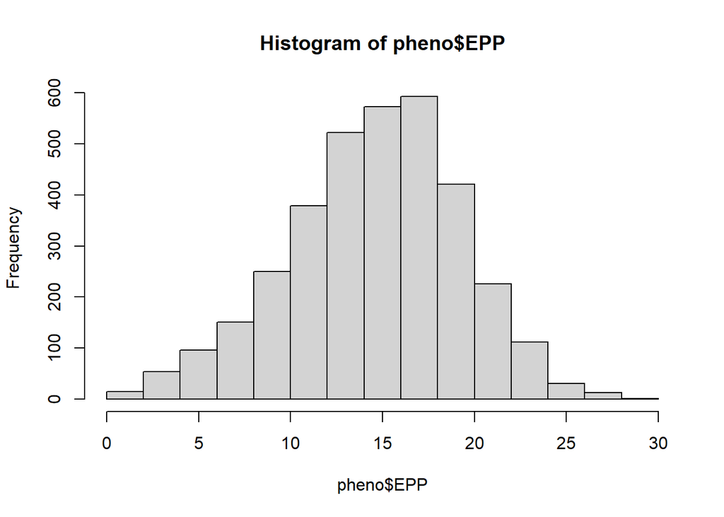

```r
hist(pheno$EPP)
```

```r
shapiro.test(pheno$EPP)
```

```
##
##  Shapiro-Wilk normality test
##
## data:  pheno$EPP
## W = 0.9893, p-value = 2.005e-15
```

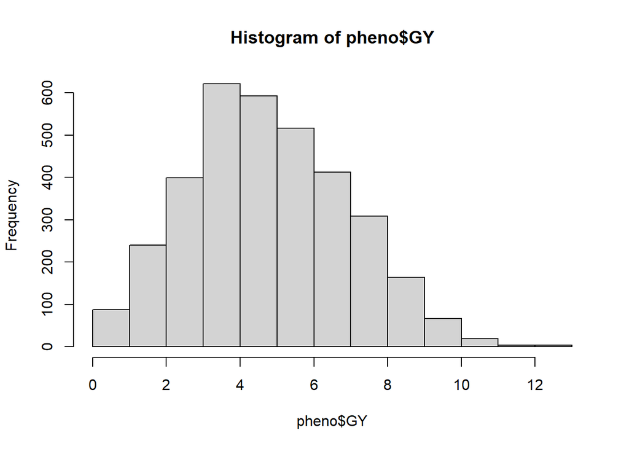

```r
hist(pheno$GY)
```

```r
shapiro.test(pheno$GY)
```

```
##
##  Shapiro-Wilk normality test
##
## data:  pheno$GY
## W = 0.99075, p-value = 3.805e-14
```

Based on the histograms and Shapiro-Wilks, all the traits does not have a normal distribution. There are different ways to get distributions more close to normality, as example, removing outliers or transforming the data. In our case we tested both approaches, however, we are still unable to get higher values than 0.05 in our Shapiro-Wilk analyses.

The main reason for this is that because we have in our dataset environments with high drought stress affecting the plants, as well as, good environments. In the moment that we pull together the data, we obtain some extremes values (caused by the drought stress), resulting in some normality deviations.

In this sense, we decide to proceed the analysis with our raw values, despite then being completely normal, once, that the main objective of this project is to understand and interpret the MET analysis and develop and/or analyze some previous developed code. Nevertheless, we strongly suggest to pay attention in the data normality and understand how (or not) it can affect the analysis results.

However, in the next codes chunks, we are still providing our code to remove outliers based on the interquartile range (IQR) equations to remove outliers (Q1 - 1.5 x IQR and Q3 + 1.5 x IQR).

## Code for removing outilers

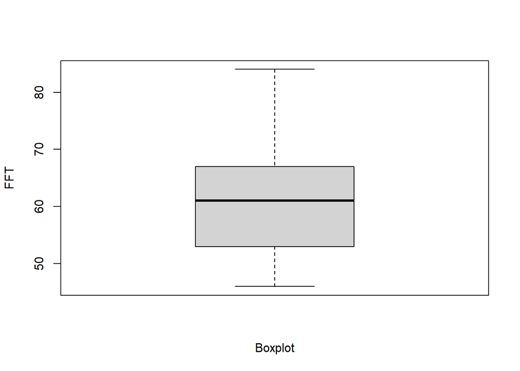

```r
# Code to get and see the boxplots

boxplot.FFT <- boxplot(pheno$FFT, xlab="Boxplot",ylab="FFT")
```

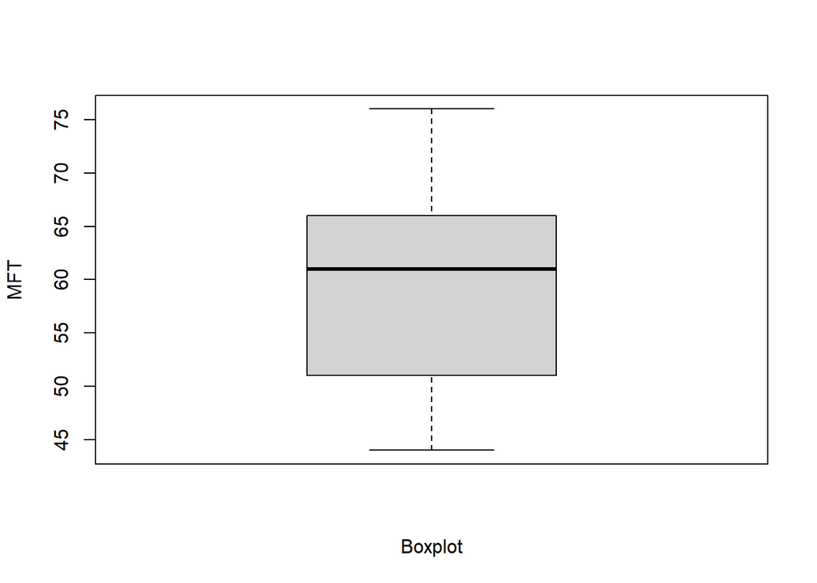

```r
boxplot.MFT <- boxplot(pheno$MFT, xlab="Boxplot",ylab="MFT")
```

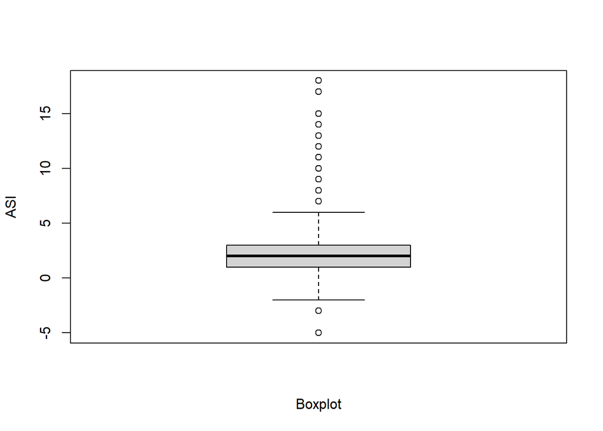

```r
boxplot.ASI <- boxplot(pheno$ASI, xlab="Boxplot",ylab="ASI")
```

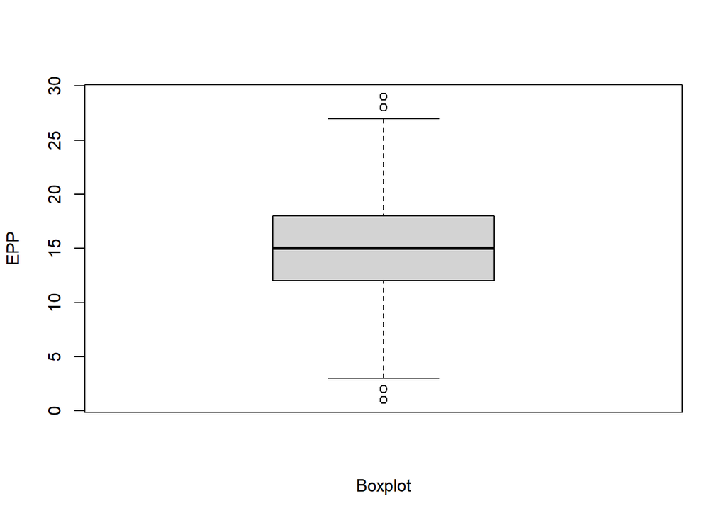

```r
boxplot.EPP <- boxplot(pheno$EPP, xlab="Boxplot",ylab="EPP")
```

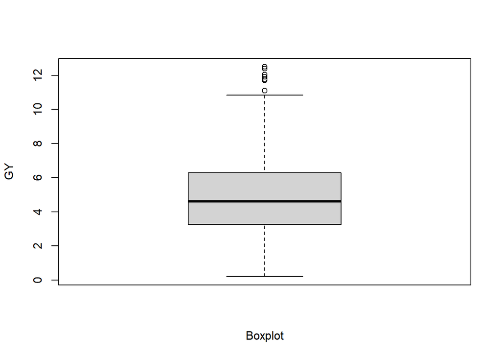

```r
boxplot.GY <- boxplot(pheno$GY, xlab="Boxplot",ylab="GY")
```

```r
# Example to remove outliers for a specific trait

#outliers <- boxplot.GY$out; outliers
#pheno <- pheno[-which(pheno$GY%in%outliers),]
#shapiro.test(pheno$GY)
```

## Information of the genotypes

The metan package has a bunch of different functions which provide valuable information to check, manipulate, and summarize data. In the next code chunks we are going to show just a small portion of them, before starting the main analyzes required by this project. However, if someone is interested in learning more about these preliminary steps, here is the link for the paper: *https://besjournals.onlinelibrary.wiley.com/doi/full/10.1111/2041-210x.13384* that give the access to supplementary information and R codes.

First, the metan package has functions that permits to check means and coefficient of variation (CV) for each genotype across the environments. It can be useful, as a first way to understand about data quality, finding the best and worst ones, as well, based on the CV, having some idea about genotype by environment interaction.

Also, using the metan functions, we can collect the descriptive analysis by trait.

```r
desc_stat(pheno, stats = "all")
```

```
## # A tibble: 5 × 34
##   variable av.dev   ci.t   ci.z    cv gmean hmean   iqr    kurt   mad   max
##   <chr>     <dbl>  <dbl>  <dbl> <dbl> <dbl> <dbl> <dbl>   <dbl> <dbl> <dbl>
## 1 ASI        1.48 0.0769 0.0769 107.   1.97  0     2     9.06    1.48  18
## 2 EPP        3.72 0.156  0.156   31.0 14.1  12.7   6    -0.0772  4.45  29
## 3 FFT        6.70 0.251  0.251   12.4 60.2  59.7  14    -1.24   10.4   84
## 4 GY         1.74 0.0713 0.0713  44.5  4.21  3.39  3.03 -0.336   2.21  12.5
## 5 MFT        7.26 0.261  0.261   13.3 58.0  57.4  14.8  -1.54   11.9   76
## # ℹ 23 more variables: mean <dbl>, median <dbl>, min <dbl>, n <dbl>,
## #   n.valid <dbl>, n.missing <dbl>, n.unique <dbl>, ps <dbl>, q2.5 <dbl>,
## #   q25 <dbl>, q75 <dbl>, q97.5 <dbl>, range <dbl>, sd.amo <dbl>, sd.pop <dbl>,
## #   se <dbl>, skew <dbl>, sum <dbl>, sum.dev <dbl>, ave.dev <dbl>,
## #   sum.sq.dev <dbl>, var.amo <dbl>, var.pop <dbl>
```

Again, the main reason to obtain these results is the nature of the environments where the data was collected, having some of them, extreme drought effects. Traits as ASI and GY are extremely affected by drought, so high CVs to these traits, in our analysis conditions are expected.

If necessary, the same function provides information about single locations, where we can confirm our hypothesis that some environments (drought ones) are pushing the CVs to high values. This code lines can be useful for removing traits or environments with high coefficient of variation.

```r
desc_stat(pheno,
          stats = ("mean, se, cv, max, min"),
          by = ENV)
```

```
## # A tibble: 40 × 7
##    ENV   variable   mean     se     cv   max   min
##    <fct> <chr>     <dbl>  <dbl>  <dbl> <dbl> <dbl>
##  1 E1    ASI       0.932 0.0701 185.    8    -5
##  2 E1    EPP      12.3   0.152   30.4  23     2
##  3 E1    FFT      64.0   0.105    4.03 73    59
##  4 E1    GY        3.53  0.053   37.0   8.36  0.24
##  5 E1    MFT      63.1   0.0785   3.06 70    58
##  6 E2    ASI       0.404 0.0581 289.    4    -3
##  7 E2    EPP      18.1   0.172   19.1  28     5
##  8 E2    FFT      64.6   0.155    4.81 73    58
##  9 E2    GY        6.70  0.078   23.4  10.7   1.31
## 10 E2    MFT      64.2   0.154    4.81 72    57
## # ℹ 30 more rows
```

Something very interesting that also the metan package provides is a function that shows the best lines (higher phenotypic values) in each of these environments. We can see that there is no replicate for GY, meaning that for each environment, there was a different best hybrid.

```r
ge_winners(pheno, ENV, GEN, resp = everything())
```

```
## # A tibble: 8 × 6
##   ENV   FFT   MFT   ASI   EPP   GY
##   <fct> <chr> <chr> <chr> <chr> <chr>
## 1 E1    146   74    146   44    287
## 2 E2    146   236   268   53    101
## 3 E3    22    253   9     191   190
## 4 E4    253   253   224   216   156
## 5 E5    270   16    270   122   234
## 6 E6    73    253   307   289   222
## 7 E7    22    176   276   83    83
## 8 E8    158   148   158   261   69
```

In addition, sometimes numbers in tables are hard to visualize and/or to take other conclusions, which are more easy by plots.

So in the next code chunk, we are showing how to do some heatmaps and line plots to collect more applied information for specific lines across the environments.

So, the first subset, shows how to collect a range of genotypes and the second subset shows how to select very specific lines.

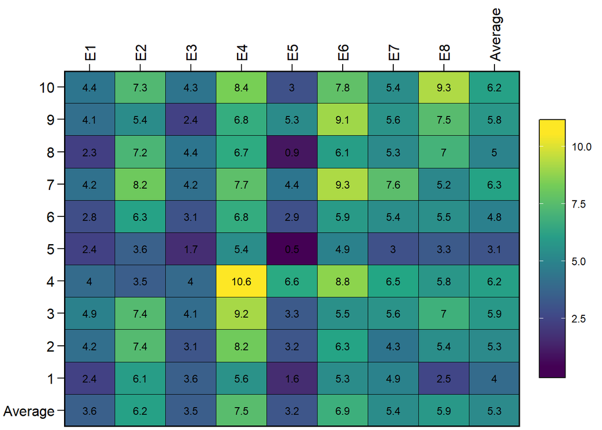

```r
subset_pheno <- pheno %>%
  filter(GEN %in% levels(GEN)[1:10]) %>%
  droplevels()
a <- ge_plot(subset_pheno, ENV, GEN, GY); a
```

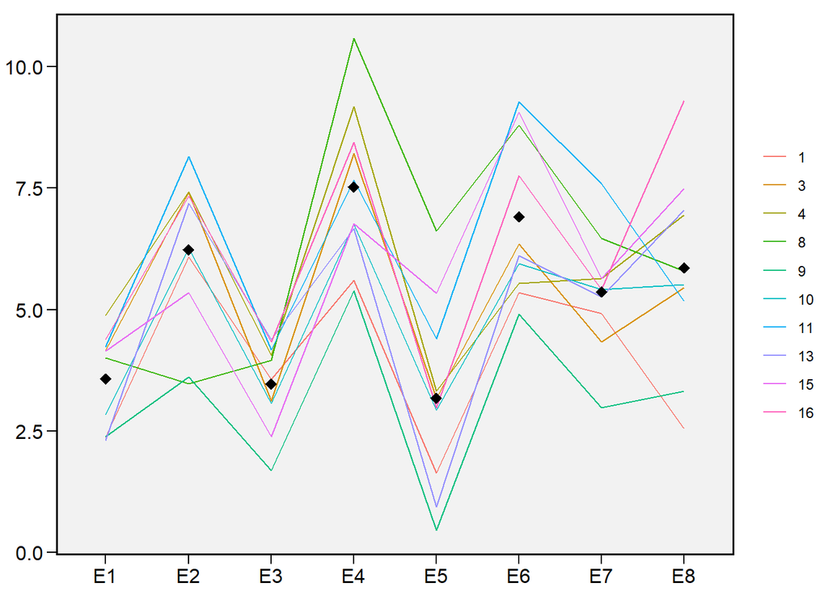

```r
b <- ge_plot(subset_pheno, ENV, GEN, GY, type = 2); b
```

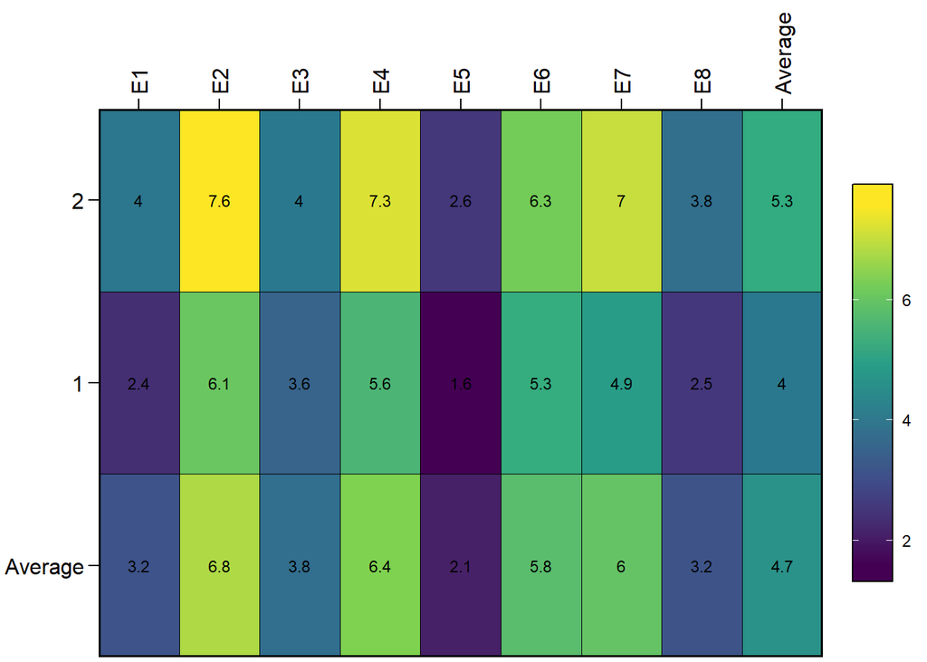

```r
subset_pheno2 <- pheno %>% filter(GEN %in% c(levels(GEN)[1], levels(GEN)[137]))
c <- ge_plot(subset_pheno2, ENV, GEN, GY); c
```

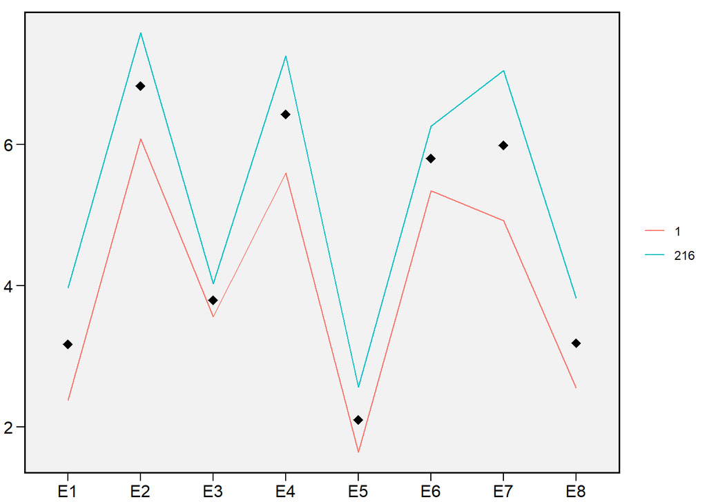

```r
d <- ge_plot(subset_pheno2, ENV, GEN, GY, type = 2); d
```

So, now, we have a good idea bout our data, we are going to do the main analyses required for this project.

# Part i) GxE analysis (+GGE analysis)

In this first step, we are doing some analysis to understand more the genotype x environment interaction. In addition, we also running some GGE analysis, aiming to understand better the group of environments (mega-environments).

For the first analysis, we are using the statgenGxE package. Thus, we need to convert the data according to the package requirements. In addition, we are running the some analysis (not all) for the subset_pheno, aiming to understand how conclusions can (or not) differ when we have more data.

```r
phenoTD <- statgenSTA::createTD(data = pheno, genotype = "GEN",
                                trial = "ENV")

phenoTD2 <- statgenSTA::createTD(data = subset_pheno, genotype = "GEN",
                                trial = "ENV")
```

Using a function from the statgenGxE, we are running a mixed model, where we are able to extract the variance components.

First, we are only checking yield.

```r
phenoVarComp <- gxeVarComp(TD = phenoTD, trait = "GY")
summary(phenoVarComp)
```

```
## Fitted model formula final mixed model
##
##  GY ~ trial + (1 | genotype) + (1 | genotype:trial)
##
## Sources of variation for fully random model:
##  GY ~ (1 | trial) + (1 | genotype) + (1 | genotype:trial)
##
##                Component % Variance expl.
## trial               2.66          52.75 %
## genotype            0.39           7.75 %
## genotype:trial      0.57          11.32 %
## residuals           1.42          28.19 %
##
## Analysis of Variance Table for fully fixed model:
##  GY ~ trial + genotype + genotype:trial
##
##                  Df Sum Sq Mean Sq  F value    Pr(>F)
## trial             7 7579.9 1082.84 824.9253 < 2.2e-16 ***
## genotype        201 1835.0    9.13   6.9550 < 2.2e-16 ***
## genotype:trial 1407 3778.9    2.69   2.0461 < 2.2e-16 ***
## residuals      1818 2386.4    1.31
## ---
## Signif. codes:  0 '***' 0.001 '**' 0.01 '*' 0.05 '.' 0.1 ' ' 1
```

More than 50% of the variation observed was due the trial. It was expected, because, as explained, these trials are conducted in different conditions of water availability.

Once we have the variance components, we also can estimate the heritability for the traits. Let’s check for all the traits.

```r
herit(phenoVarCompGY)
```

```
## [1] 0.7091811
```

```r
herit(phenoVarCompFFT)
```

```
## [1] 0.7428868
```

```r
herit(phenoVarCompMFT)
```

```
## [1] 0.787534
```

```r
herit(phenoVarCompASI)
```

```
## [1] 0.6839426
```

```r
herit(phenoVarCompEPP)
```

```
## [1] 0.7213632
```

It is a little surprising to get a high heritability (0.71) for grain yield (quantitative trait), specifically for the trials conditions from this dataset. Something very interesting which this package permits us is to predict the genotype main effect based on the mixed model analysis.

```r
for (trait in traits) {
  var_name <- paste0("phenoVarComp", trait)
  phenoVarComp_obj <- get(var_name)
  predGeno <- predict(phenoVarComp_obj)
  print(head(predGeno))
  predGenoTrial <- predict(phenoVarComp_obj, predictLevel = "trial")
  print(head(predGenoTrial))
}
```

```
##   genotype predictedValue
## 1        1       4.075380
## 2        3       4.829526
## 3        4       5.336766
## 4        8       5.579351
## 5        9       3.116764
## 6       10       4.544380
##   genotype trial predictedValue
## 1        1    E1       2.594241
## 2        3    E1       3.906923
## 3        4    E1       4.489299
## 4        8    E1       4.113286
## 5        9    E1       2.259634
## 6       10    E1       3.066884
##   genotype predictedValue
```

[output cut: 55 more lines]

In this example, we can see that for example based on the mixed model and evaluation across all the locations for GY, the genotype 8 is the best, and the genotype 9 is the worst, based on the predictions.

Extracting the variance components, getting the heritability, being able to do predictions are main analysis in the GxE spectrum. However, we would like to go more deep, and also finding something is very useful for some research areas, as example plant breeding, mega environments. To complete this task, we are going back to the metan package.

Initially, we need to fit a gge model. Here, we are testing with the subset_pheno.

```r
gge_model <- gge(pheno, ENV, GEN, GY)
gge_model2 <- gge(subset_pheno, ENV, GEN, GY)
```

As the statgenGxE, we also can do predictions, however, because, the models work a little different, the results will be similar, but not the same results.

```r
predict(gge_model)
```

```
## $GY
## # A tibble: 202 × 8
##       E1    E2    E3    E4    E5    E6    E7    E8
##  * <dbl> <dbl> <dbl> <dbl> <dbl> <dbl> <dbl> <dbl>
##  1  2.94  5.79  2.56  5.82  2.23  5.51  4.52  2.62
##  2  3.70  7.04  3.57  7.53  3.07  7.03  5.42  5.30
##  3  3.99  7.48  3.96  8.04  3.40  7.57  5.74  6.74
##  4  4.26  8.05  4.22  9.20  3.65  8.21  6.15  5.73
##  5  2.43  4.83  2.01  4.12  1.74  4.43  3.83  3.00
##  6  3.37  6.42  3.20  6.44  2.75  6.32  4.98  5.43
##  7  4.26  8.06  4.21  9.25  3.64  8.21  6.16  5.51
##  8  3.46  6.50  3.38  6.33  2.89  6.45  5.04  6.91
##  9  3.82  7.13  3.83  7.29  3.27  7.19  5.49  7.64
## 10  4.15  7.64  4.28  7.91  3.65  7.83  5.87  9.18
## # ℹ 192 more rows
```

```r
predict(gge_model2)
```

```
## $GY
## # A tibble: 10 × 8
##       E1    E2    E3    E4    E5    E6    E7    E8
##  * <dbl> <dbl> <dbl> <dbl> <dbl> <dbl> <dbl> <dbl>
##  1  2.49  5.28  2.71  5.87 1.34   5.26  4.14  3.72
##  2  3.55  6.63  3.58  7.40 2.79   6.68  5.30  6.08
##  3  3.99  7.52  4.03  7.95 3.11   7.11  5.74  7.25
##  4  4.37  4.09  3.21  9.41 6.94   9.46  6.57  5.66
##  5  2.00  4.36  2.23  5.23 0.938  4.75  3.63  2.45
##  6  3.27  6.14  3.31  7.01 2.51   6.36  5.00  5.36
##  7  4.23  6.60  3.88  8.58 4.47   8.01  6.14  7.03
##  8  3.35  7.81  3.83  6.78 1.31   5.74  4.93  6.52
##  9  4.11  5.61  3.53  8.60 5.01   8.24  6.09  6.23
## 10  4.37  8.28  4.42  8.44 3.41   7.50  6.14  8.27
```

The metan package has a variety of biplots that explore the GGE (Genotype plus GxE), but, for practical purposes, we are only selecting the biplot that ranks the environments, bringing, at some degree, the relationship between environments.

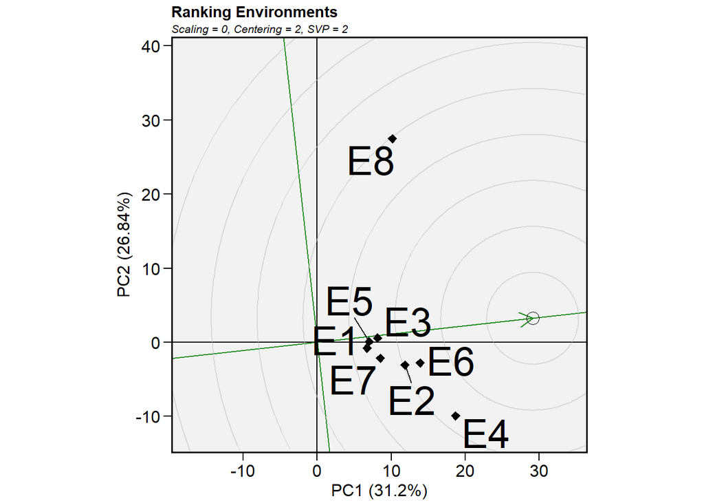

```r
biplot_ranking <- plot(gge_model,
type = 6,
col.gen = "black",
col.env = "black",
size.text.env = 10,
axis_expand = 1.5)
biplot_ranking
```

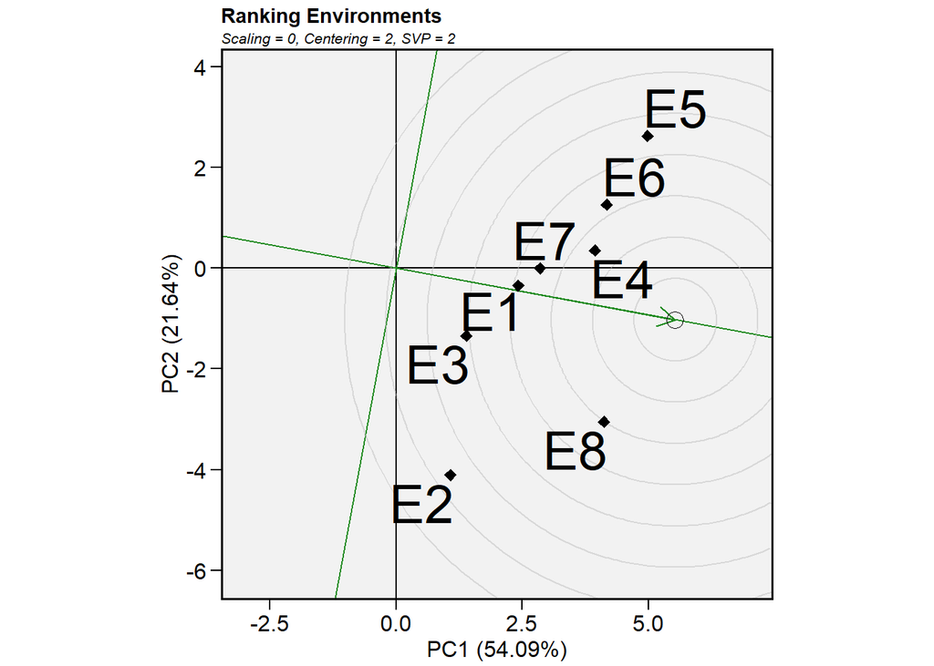

```r
biplot_ranking <- plot(gge_model2,
type = 6,
col.gen = "black",
col.env = "black",
size.text.env = 10,
axis_expand = 1.5)
biplot_ranking
```

However, these conclusions changes drastically when we only evaluated a small subset of hybrids, being a good example of how the sample size affects some important conclusions in MET analysis.

Below is the code to rank the environments only based on GY, what makes more sense, for example, in the breeding research area. However, we also are providing some code (loop) to test for all the traits.

# Part iii) AMMI analysis

The AMMI stands for the additive main effect and multiplicative interaction. In this model, the additive main effects are the genotypes and the trials, coming from the ANOVA results, where the multiplicative interaction factors are coming from a PCA analysis on the interactions residuals (genotype by environment means after adjustment for additive genotype and environment effects).

Therefore, in the code chunk below we are running this model only for GY trait, aiming to evaluate the genotypes performance across the environments, and finding the stable ones.

Also, from here, we decide, to run the analysis with a subset of genotypes, to show how the graphs look when we have a small or big number of genotypes and how it can affect our conclusions.

```r
AMMI_model <- performs_ammi(pheno, ENV, GEN, REP, GY)
```

```
## variable GY
## ---------------------------------------------------------------------------
## AMMI analysis table
## ---------------------------------------------------------------------------
##     Source   Df Sum Sq Mean Sq F value    Pr(>F) Proportion Accumulated
##        ENV    7   7580 1082.84   90.57  1.28e-07         NA          NA
##   REP(ENV)    9    108   11.96    9.49  3.08e-14         NA          NA
##        GEN  201   1835    9.13    7.25 4.44e-128         NA          NA
##    GEN:ENV 1407   3779    2.69    2.13  5.99e-52         NA          NA
##        PC1  207   2635   12.73   10.11  0.00e+00       37.9        37.9
##        PC2  205   1303    6.36    5.04  0.00e+00       18.7        56.6
##        PC3  203   1047    5.16    4.09  0.00e+00       15.0        71.6
##        PC4  201    829    4.13    3.28  0.00e+00       11.9        83.6
##        PC5  199    561    2.82    2.24  0.00e+00        8.1        91.6
##        PC6  197    360    1.83    1.45  1.00e-04        5.2        96.8
##        PC7  195    224    1.15    0.91  8.01e-01        3.2       100.0
##  Residuals 1809   2279    1.26      NA        NA         NA          NA
##      Total 4840  22540    4.66      NA        NA         NA          NA
## ---------------------------------------------------------------------------
##
## All variables with significant (p < 0.05) genotype-vs-environment interaction
## Done!
```

```r
AMMI_model_2 <- performs_ammi(subset_pheno, ENV, GEN, REP, GY)
```

```
## variable GY
## ---------------------------------------------------------------------------
## AMMI analysis table
## ---------------------------------------------------------------------------
##     Source  Df  Sum Sq Mean Sq F value   Pr(>F) Proportion Accumulated
##        ENV   7  373.69  53.385  69.460 4.10e-07         NA          NA
##   REP(ENV)   9    6.92   0.769   0.599 7.94e-01         NA          NA
##        GEN   9  150.26  16.696  13.009 1.38e-12         NA          NA
##    GEN:ENV  63  159.39   2.530   1.971 2.05e-03         NA          NA
##        PC1  15  125.53   8.369   6.520 0.00e+00       47.5        47.5
##        PC2  13   64.78   4.983   3.880 1.00e-04       24.5        72.0
##        PC3  11   42.23   3.839   2.990 2.20e-03       16.0        87.9
##        PC4   9   18.15   2.016   1.570 1.38e-01        6.9        94.8
##        PC5   7    7.33   1.047   0.820 5.74e-01        2.8        97.6
##        PC6   5    4.66   0.931   0.730 6.03e-01        1.8        99.3
##        PC7   3    1.81   0.603   0.470 7.04e-01        0.7       100.0
##  Residuals  81  103.95   1.283      NA       NA         NA          NA
##      Total 232 1058.70   4.563      NA       NA         NA          NA
## ---------------------------------------------------------------------------
##
## All variables with significant (p < 0.05) genotype-vs-environment interaction
## Done!
```

The values clearly showed a strong genotype x environment interaction in both scenarios.

There are different ways to explore the results obtained by the AMMI model. One good way is developing a biplot, where we are using as axis our trait and the first PC.

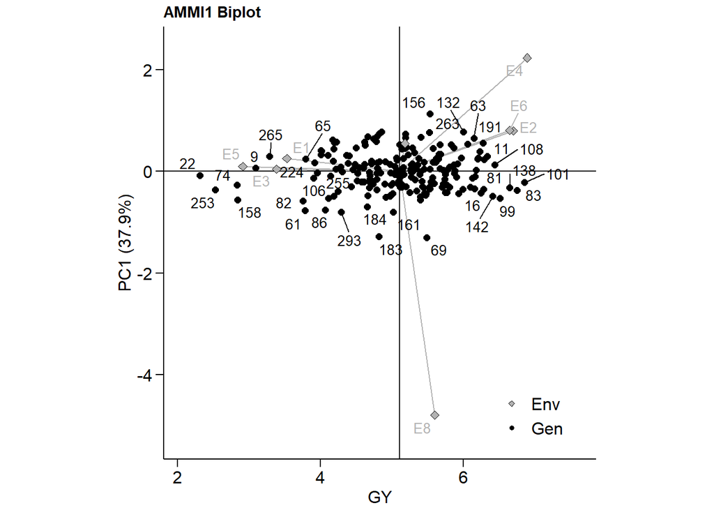

```r
AMMI_biplot_GY <- plot_scores(AMMI_model,
col.gen = "black",
col.env = "gray70",
col.segm.env = "gray70",
plot_theme = theme_metan_minimal())
AMMI_biplot_GY
```

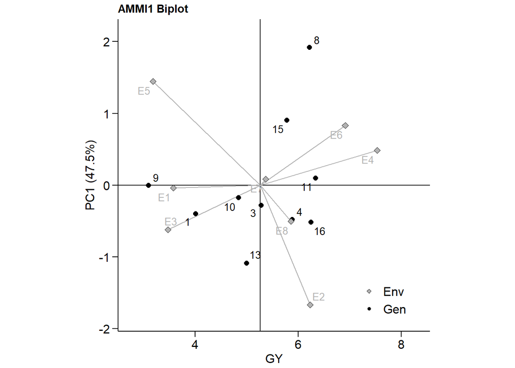

```r
AMMI_biplot_GY2 <- plot_scores(AMMI_model_2,
col.gen = "black",
col.env = "gray70",
col.segm.env = "gray70",
plot_theme = theme_metan_minimal())
AMMI_biplot_GY2
```

In this biplot we can take a look, from each environments are more similar, or thinking in the other side, finding the environment that have the same best lines. Also we need to pay attention in the quadrants, as well as, in the directions of our environments, because it represents the relationship between environments. For example, E6 and E2 are very similar to each other, however, they are completely different from the E5, E1, E3. The hybrid 101 and 138 apparently have high yield on the environment 6 and 2 and it is low yield in environments 5,3, and 1.

The conclusions are very similar for our small dataset, however we have some deviation about the environments correlation.

We also can check if we obtain similar results comparing PC1 and PC2.

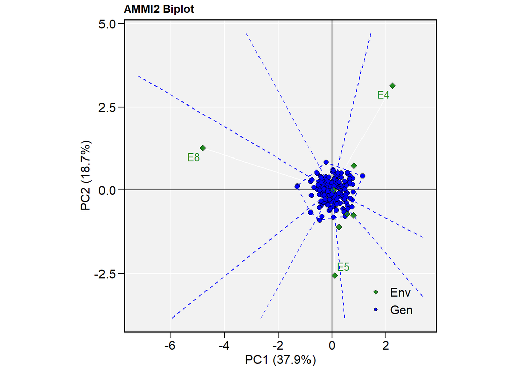

```r
AMMI_biplot_PCs <- plot_scores(AMMI_model,
type = 2,
polygon = T,
col.segm.env = "#FFFFFF00", # Transparent
axis.expand = 1.5,
plot_theme = theme_metan(grid = "both"))
AMMI_biplot_PCs
```

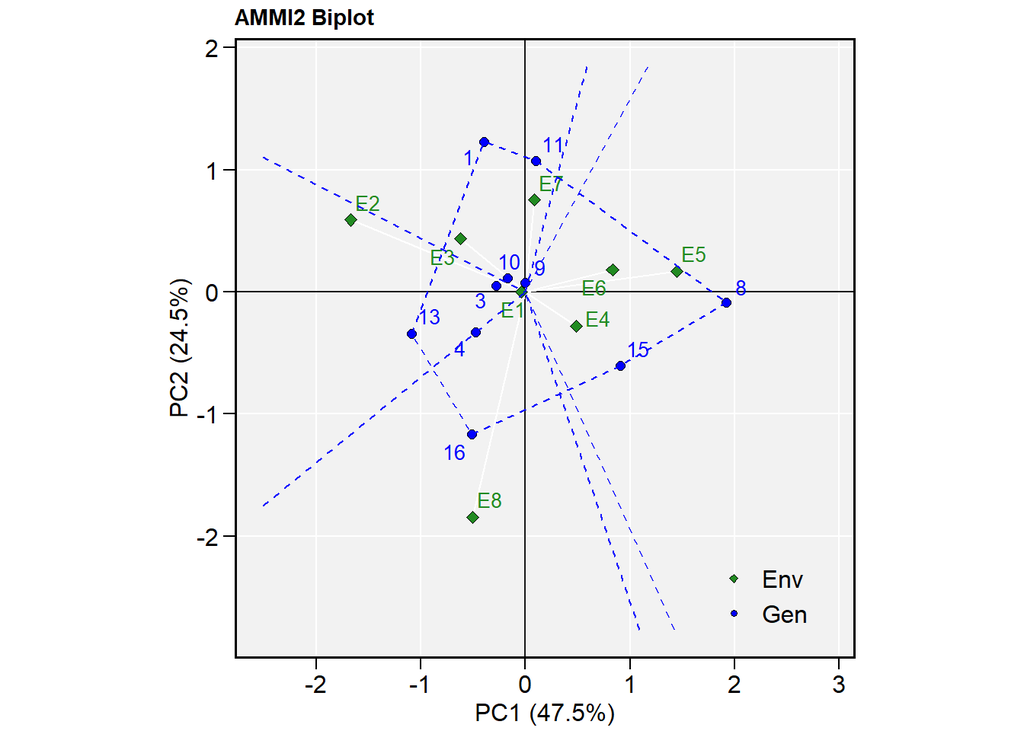

```r
AMMI_biplot_PCs_2 <- plot_scores(AMMI_model_2,
type = 2,
polygon = T,
col.segm.env = "#FFFFFF00", # Transparent
axis.expand = 1.5,
plot_theme = theme_metan(grid = "both"))
AMMI_biplot_PCs_2
```

The results are pretty the same.

Also we can check “which-won-where” based on our AMMI model.

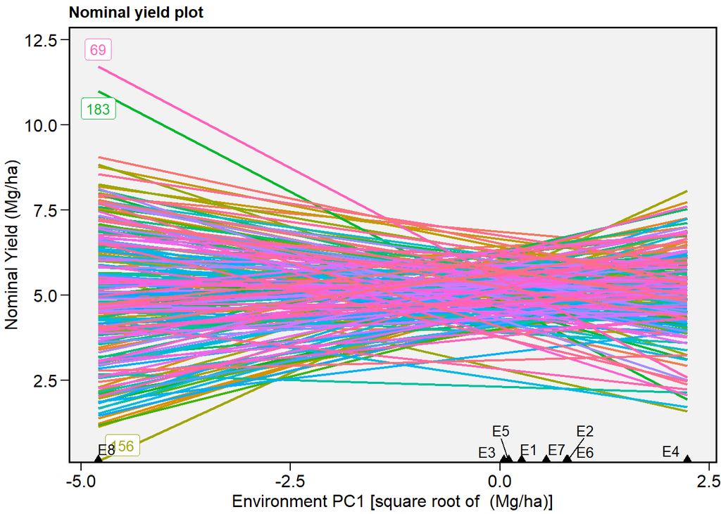

```r
AMMI_biplot_nominal <- plot_scores(AMMI_model, type = 4)
AMMI_biplot_nominal
```

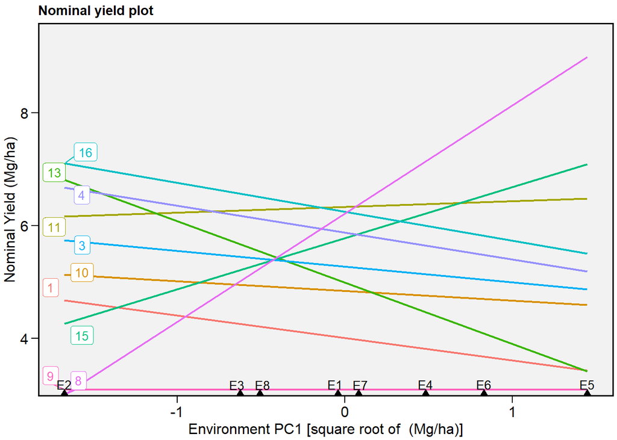

```r
AMMI_biplot_nominal_2 <- plot_scores(AMMI_model_2, type = 4)
AMMI_biplot_nominal_2
```

In these plots, we can observe the change in rankings, as example, in the first plot where the line 69 is a good one in the E8, however, its rankings drops drastically across better environments.

Again, we only conducted for GY, because it the most important trait in plant breeding, and makes more sense to take conclusions of genotype stability based on this trait.

# Part iii) GGI analysis

The GGI stands for genotype by group interaction. The main differences from the previous analysis is that now, we are grouping some hybrids according to their similarities, considering all the traits, and estimating group-by-environment interactions.

So, the package uses a function to cluster genotypes based on their means for all the traits. Again, here, we are using the pheno and subset_pheno.

```r
mean_gen <-
pheno %>%
means_by(GEN) %>%
column_to_rownames("GEN")
d2 <- clustering(mean_gen)

mean_gen_2 <-
subset_pheno %>%
means_by(GEN) %>%
column_to_rownames("GEN")
d2_2 <- clustering(mean_gen_2)
```

After clustering the genotypes, we can plot this cluster in a dendrogram shape, also, to identify how many cluster we got in this analysis.

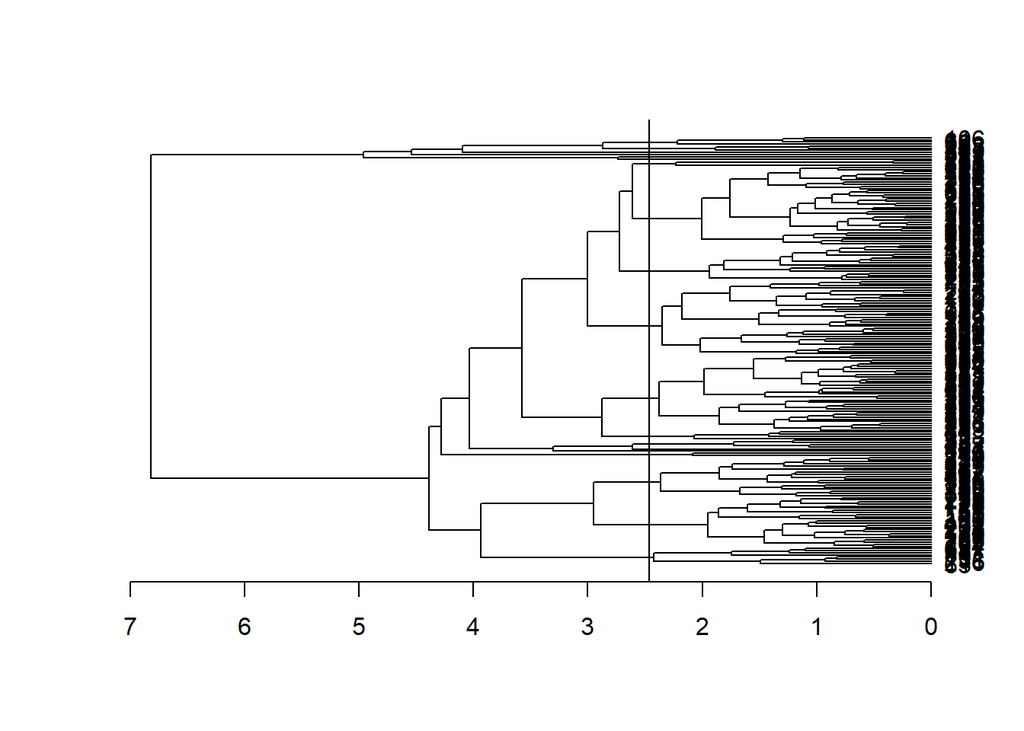

```r
plot(d2)
```

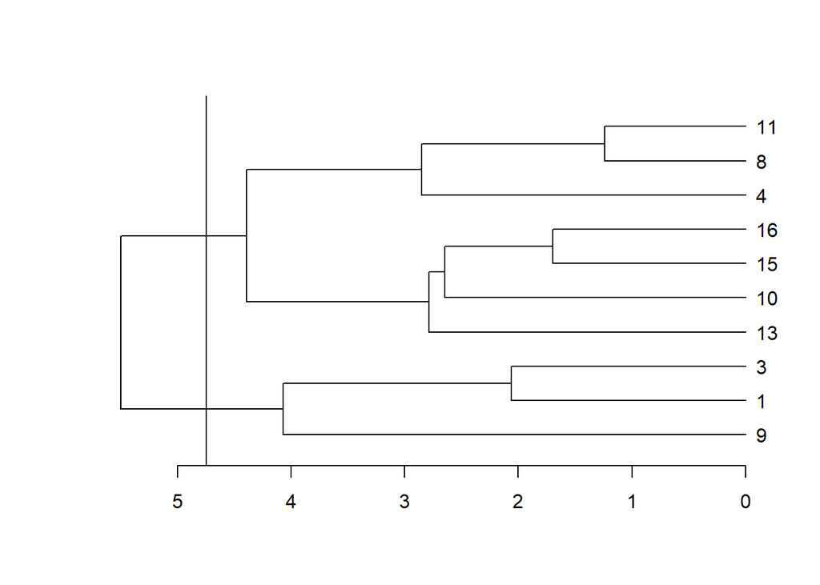

```r
plot(d2_2)
```

For the biggest dataset, we have a lot of cluster, meaning that small number of genotypes in each cluster, while in the subset pheno, based on the threshold, we only have two cluster.

One big problem of this clustering analysis is that we do not know if all the traits are in fact contributing for the cluster building, so, we need to find each ones are important and each ones can be removed.

```r
sel_var <- clustering(mean_gen, selvar = TRUE)
```

```
## FFT excluded in this step |============                                   | 25% GY excluded in this step |========================                        | 50% ASI excluded in this step |===================================            | 75% MFT excluded in this step |==============================…
## --------------------------------------------------------------------------
##
## Summary of the adjusted models
## --------------------------------------------------------------------------
##    Model excluded cophenetic remaining cormantel    pvmantel
##  Model 1        -  0.6965867         5 1.0000000 0.000999001
##  Model 2      FFT  0.7271614         4 0.9445143 0.000999001
##  Model 3       GY  0.7548018         3 0.9468654 0.000999001
##  Model 4      ASI  0.7665665         2 0.8922313 0.000999001
## --------------------------------------------------------------------------
## Suggested variables to be used in the analysis
## --------------------------------------------------------------------------
## The clustering was calculated with the  Model 4
## The variables included in this model were...
##  MFT EPP
## --------------------------------------------------------------------------
```

```r
sel_var2 <- clustering(mean_gen_2, selvar = TRUE)
```

```
## ASI excluded in this step |============                                   | 25% GY excluded in this step |========================                        | 50% MFT excluded in this step |===================================            | 75% FFT excluded in this step |==============================…
## --------------------------------------------------------------------------
##
## Summary of the adjusted models
## --------------------------------------------------------------------------
##    Model excluded cophenetic remaining cormantel    pvmantel
##  Model 1        -  0.6928961         5 1.0000000 0.000999001
##  Model 2      ASI  0.7164971         4 0.9864986 0.000999001
##  Model 3       GY  0.7426920         3 0.9756303 0.000999001
##  Model 4      MFT  0.7307509         2 0.9710941 0.000999001
## --------------------------------------------------------------------------
## Suggested variables to be used in the analysis
## --------------------------------------------------------------------------
## The clustering was calculated with the  Model 3
## The variables included in this model were...
##  FFT MFT EPP
## --------------------------------------------------------------------------
```

# Part iv) FW analysis

The FW stands for Finlay-Wilkinson analysis, where the GxE interaction is estimated heterogeneity of the slopes of a regression of individual genotypic performance on an environmental index.

```r
phenoFW <- gxeFw(TD = phenoTD, trait = "GY")
summary(phenoFW)
```

```
## Environmental effects
## =====================
##   Trial     EnvEff  SE_EnvEff  EnvMean SE_EnvMean Rank
## 1    E1 -1.5626337 0.05086093 3.539316  0.4311904    6
## 2    E2  1.5685308 0.05996941 6.667806  0.5341492    3
## 3    E3 -1.6566421 0.05086093 3.445388  0.4449041    7
## 4    E4  1.8280238 0.08139299 6.927077  0.5805836    1
## 5    E5 -2.2546431 0.05996941 2.847898  0.5429888    8
## 6    E6  1.5963523 0.05996941 6.695603  0.5390234    2
## 7    E7  0.0621412 0.05086093 5.162703  0.3412076    5
## 8    E8  0.4188708 0.08139299 5.519128  0.3689585    4
##
## Anova
## =====
##                 Df  Sum Sq Mean Sq  F value    Pr(>F)
## Trial            7  7579.9 1082.84 581.7270 < 2.2e-16 ***
## Genotype       201  1835.0    9.13   4.9046 < 2.2e-16 ***
## Sensitivities  201   536.4    2.67   1.4336  0.000101 ***
## Residual      3024  5628.9    1.86
## Total         3433 15580.2    4.54
## ---
## Signif. codes:  0 '***' 0.001 '**' 0.01 '*' 0.05 '.' 0.1 ' ' 1
##
## Most sensitive genotypes
## ========================
##  Genotype  GenMean SE_GenMean Rank     Sens   SE_Sens MSdeviation
##        66 5.681267  0.3380492    1 1.710121 0.2224153    1.881192
##       196 5.074181  0.3380492    2 1.680427 0.2224153    1.569990
##        40 6.147283  0.3380492    3 1.618015 0.2224153    3.181711
##       222 5.626621  0.3380492    4 1.530812 0.2224153    1.975627
##        63 5.269591  0.3380492    5 1.477241 0.2224153    1.299583
```

```r
phenoFW2 <- gxeFw(TD = phenoTD2, trait = "GY")
summary(phenoFW2)
```

```
## Environmental effects
## =====================
##   Trial     EnvEff SE_EnvEff  EnvMean SE_EnvMean Rank
## 1    E1 -1.7015057 0.2325573 3.561427  0.4326692    6
## 2    E2  1.0360834 0.2742051 6.296761  0.4415681    3
## 3    E3 -1.7645439 0.2325573 3.498441  0.4419319    7
## 4    E4  2.1428439 0.3721626 7.402610  0.6306224    1
## 5    E5 -2.1220884 0.2742051 3.141190  0.4983030    8
## 6    E6  1.6418817 0.2742051 6.902061  0.5400925    2
## 7    E7  0.1025548 0.2325573 5.364002  0.3366600    5
## 8    E8  0.6647743 0.3721626 5.925758  0.3907917    4
##
## Anova
## =====
##                Df Sum Sq Mean Sq F value    Pr(>F)
## Trial           7 373.69  53.385 29.2191 < 2.2e-16 ***
## Genotype        9 150.26  16.696  9.1383  7.13e-11 ***
## Sensitivities   9   7.17   0.796  0.4358    0.9139
## Residual      144 263.09   1.827
## Total         169 794.21   4.699
## ---
## Signif. codes:  0 '***' 0.001 '**' 0.01 '*' 0.05 '.' 0.1 ' ' 1
##
## Most sensitive genotypes
## ========================
##  Genotype  GenMean SE_GenMean Rank     Sens   SE_Sens MSdeviation
##         4 6.586575  0.3306879    1 1.205905 0.2165685   1.5558270
##         8 5.032008  0.3306879    2 1.199806 0.2165685   1.8503382
##        10 6.089283  0.3306879    3 1.164750 0.2165685   1.3596097
##         9 5.684087  0.3306879    4 1.027283 0.2165685   2.0816706
##        11 5.208903  0.3306879    5 1.001658 0.2165685   0.9558142
```

It is interesting that we in the FW output, we can obtain also environment rankings based on this model, as well as, getting some environment effects per se and in environments effects on the hybrids.

Additionally, we can also plot, to take a look how the hybrids performed across the environments and select some specific hybrids based on the rankings that we got in the previous code.

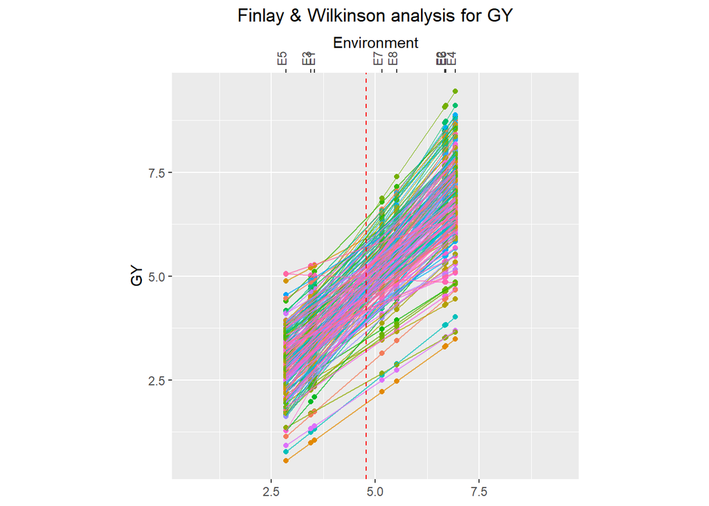

```r
plot(phenoFW, plotType = "line")
```

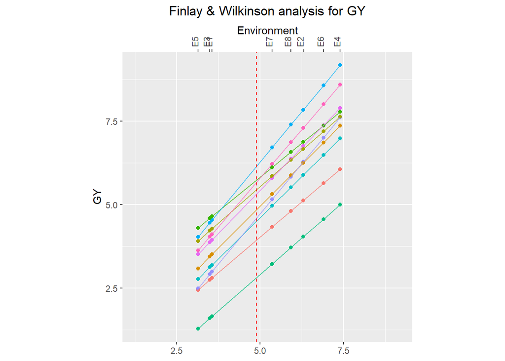

```r
plot(phenoFW2, plotType = "line")
```

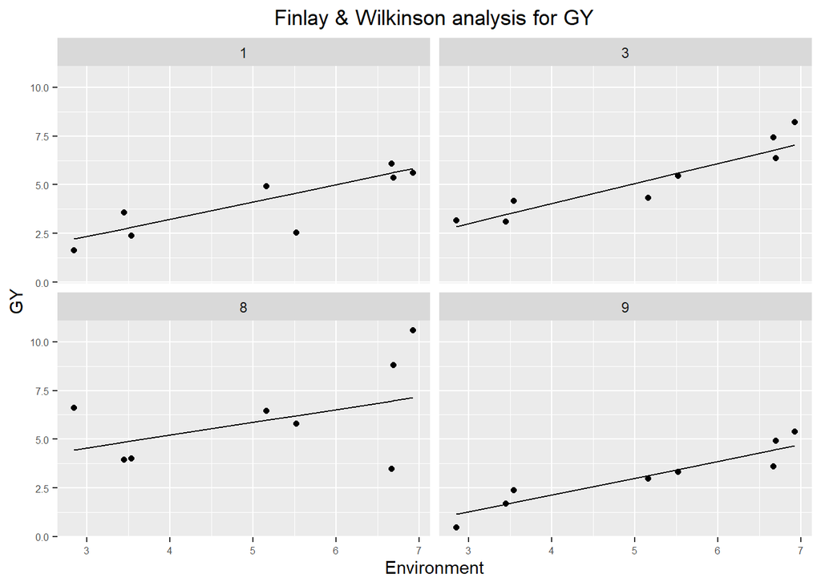

```r
plot(phenoFW, plotType = "trellis", genotypes = c("1", "3", "8", "9"))
```

Also, it is possible check the hybrids performance through a scatter plot, comparing their distribution in the best and worst environment.

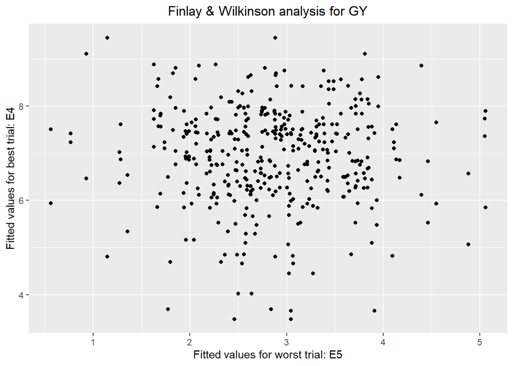

```r
plot(phenoFW, plotType = "scatterFit")
```

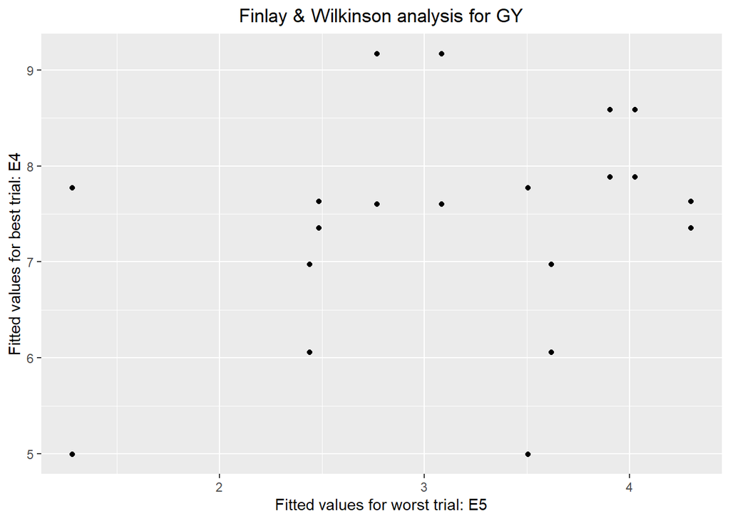

```r
plot(phenoFW2, plotType = "scatterFit")
```

# References

*Crossa, J., Y. Beyene, S. Kassa, P. Pérez-Rodríguez, J. M. Hickey, et al., 2013 Genomic prediction in maize breeding populations with genotyping-by-sequencing. G3: Genes|Genomes|Genetics (Bethesda) 3, 1903–1926. https://doi.org/10.1534/g3.113.008227*

*Dias, K.O.D.G., Gezan, S.A., Guimarães, C.T. et al. Improving accuracies of genomic predictions for drought tolerance in maize by joint modeling of additive and dominance effects in multi-environment trials. Heredity 121, 24–37 (2018). https://doi.org/10.1038/s41437-018-0053-6*

*Montesinos-López, O. A., A. Montesinos-López, J. Crossa, F. Toledo,O. Pérez-Hernández et al., 2016 A Genomic Bayesian Multi-trait and Multi-environment model. G3: Genes|Genomes|Genetics (Bethesda),6:2725–2744. https://doi.org/10.1534/g3.116.032359*

*Montesinos-López, O. A., A. Montesinos-López, J. Crossa, J. C. Montesinos-López, F. J. Luna-Vázquez et al., 2017 A Variational Bayes Genomic-Enabled Prediction Method with Genotype · Environment Interaction. G3: Genes, Genomes. Genetics 7: 1833–1853*

*Osval A Montesinos-López, Abelardo Montesinos-López, Francisco Javier Luna-Vázquez, Fernando H Toledo, Paulino Pérez-Rodríguez, Morten Lillemo, José Crossa, An R Package for Bayesian Analysis of Multi-environment and Multi-trait Multi-environment Data for Genome-Based Prediction, G3 Genes|Genomes|Genetics, Volume 9, Issue 5, 1 May 2019, Pages 1355–1369, https://doi.org/10.1534/g3.119.400126*

*Olivoto T, Lúcio AD. metan: An R package for multi-environment trial analysis. Methods Ecol Evol. 2020; 11: 783–789. https://doi.org/10.1111/2041-210X.13384*